# Chapter 9

jim108@gmx.net

6/2/2020

## 9E1.

Which of the following is a requirement of the simple Metropolis algorithm? 1. The parameters must be discrete. 1. The likelihood function must be Gaussian. 1. The proposal distribution must be symmetric.

Sol.: 3.

## 9E2.

Gibbs sampling is more efficient than the Metropolis algorithm. How does it achieve this extra efficiency? Are there any limitations to the Gibbs sampling strategy?

Sol.: Gibbs sampling can be slow because the direction in which new points are sampled is limited.

## 9E3.

Which sort of parameters can Hamiltonian Monte Carlo not handle? Can you explain why?

Sol.: Discrete parameters because it uses the gradient to predict a new point.

## 9E4.

Explain the difference between the effective number of samples, n_eff as calculated by Stan, and the actual number of samples.

Sol.: The actual number of samples includes correlated samples. n_eff is an approximation of the number of independent samples.

## 9E5.

Which value should Rhat approach, when a chain is sampling the posterior distribution correctly?

Sol.: 1

## 9E6.

Sketch a good trace plot for a Markov chain, one that is effectively sampling from the posterior distribution. What is good about its shape? Then sketch a trace plot for a malfunctioning Markov chain. What about its shape indicates malfunction?

Sol.:

```r
y <- c(-1,1)
```

```r
set.seed(11)
m9.3 <- ulam(
    alist(
        y ~ dnorm( mu , sigma ) ,
        mu <- alpha ,
        alpha ~ dnorm( 1 , 10 ) ,
        sigma ~ dexp( 1 )
    ) , data=list(y=y) , chains=1 )
```

```
## Trying to compile a simple C file
```

```r
precis( m9.3 )
```

```
##            mean        sd       5.5%    94.5%    n_eff     Rhat4
## alpha 0.2162475 1.1750492 -1.4682154 2.078566 177.4567 0.9990841
## sigma 1.5422032 0.7601981  0.7360638 2.885568 183.3116 1.0070333
```

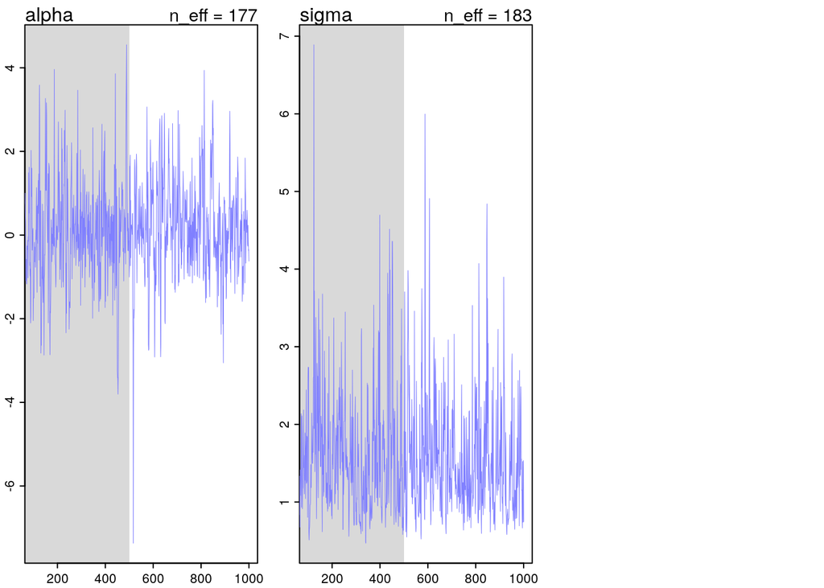

```r
traceplot( m9.3)
```

- A good shape is indicated by values varying from one sample to the next quite a lot.

```r
set.seed(11)
m9.2 <- ulam(
    alist(
        y ~ dnorm( mu , sigma ) ,
        mu <- alpha ,
        alpha ~ dnorm( 0 , 1000 ) ,
        sigma ~ dexp( 0.0001 )
    ) , data=list(y=y) , chains=1 )
```

```
## Trying to compile a simple C file
```

```r
precis( m9.2 )
```

[output not shown]

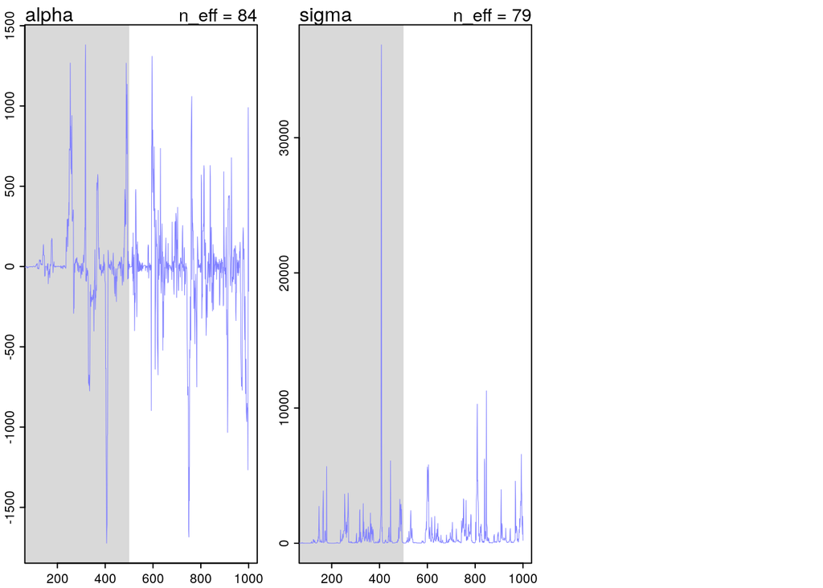

```r
traceplot( m9.2)
```

- The Malfunction is indicated by samples stick a one value for some time.

## 9M1.

Given: Rugged data.

Want: Model with prior `dunif(0,10)` and `dexp(1)` for `sigma`. Difference to the previous model.

Sol.:

```r
data(rugged)
d <- rugged
d <- d[d$cont_africa==1, c("isocode", "country", "rugged", "rgdppc_2000")]
d$log_gdp <- log(d$rgdppc_2000)
d <- d[ complete.cases(d$rgdppc_2000) ,]
d$L <- d$log_gdp / mean(d$log_gdp)
d$rugged_std <- d$rugged / max(d$rugged)
d$R <- d$rugged_std - mean(d$rugged_std)
summary(data.frame(d$L, d$R))
```

```
##       d.L              d.R
##  Min.   :0.8209   Min.   :-0.16039
##  1st Qu.:0.9051   1st Qu.:-0.13378
##  Median :0.9834   Median :-0.08025
##  Mean   :1.0000   Mean   : 0.00000
##  3rd Qu.:1.0905   3rd Qu.: 0.01359
##  Max.   :1.3084   Max.   : 0.82107
```

```r
m9M1q <- quap(
    alist(
        L ~ dnorm( mu , sigma ) ,
        mu <- a + b*R ,
        a ~ dnorm( 1 , 0.1 ) ,
        b ~ dnorm( 0 , 0.3 ) ,
        sigma ~ dexp( 1 )
    ) , data=d )
precis( m9M1q , depth=2 )
```

```
##            mean         sd       5.5%     94.5%
## a     1.0000010 0.01678709 0.97317197 1.0268300
## b     0.1465181 0.08038202 0.01805215 0.2749841
## sigma 0.1192012 0.01202015 0.09999068 0.1384117
```

```r
m9M1u <- ulam(
    alist(
        L ~ dnorm( mu , sigma ) ,
        mu <- a + b*R ,
        a ~ dunif( 0 , 10 ) ,
        b ~ dunif( 0 , 10 ) ,
        sigma ~ dexp( 1 )
    ) , data=d, chains=4 , cores=4 )
```

```
## Trying to compile a simple C file
```

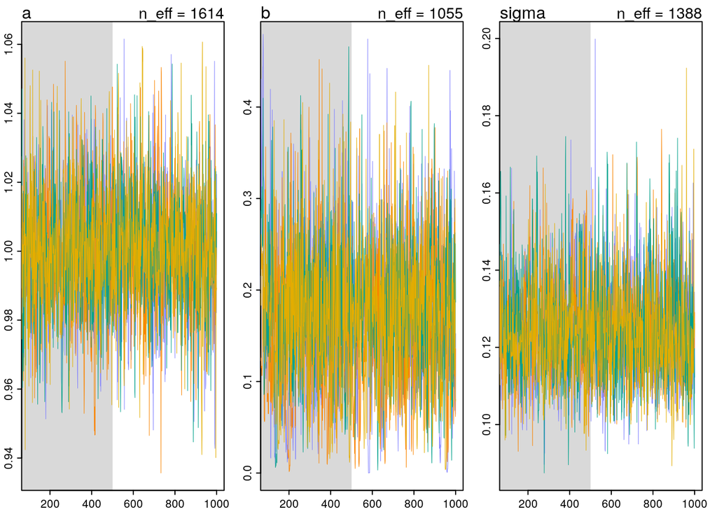

```r
traceplot(m9M1u)
```

```r
precis(m9M1u)
```

```
##            mean         sd       5.5%     94.5%    n_eff    Rhat4
## a     1.0000084 0.01778026 0.97233090 1.0271541 1614.164 1.000486
## b     0.1666998 0.07770704 0.04648092 0.2946404 1055.038 1.001945
## sigma 0.1243291 0.01358867 0.10544408 0.1472970 1388.214 1.001942
```

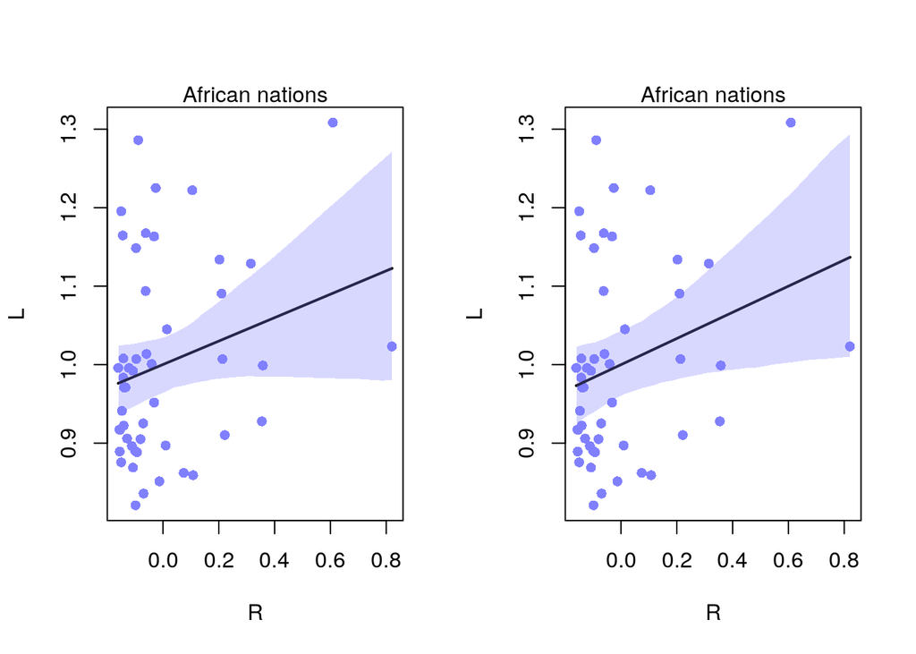

```r
plot_rugged_posterior <- function(model,d){
  plot( d$R , d$L , pch=16 , col=rangi2 ,
    xlab="R" , ylab="L" ,
    xlim=c(min(d$R),max(d$R)) )
  R.seq <- seq( from=min(d$R) , to=max(d$R) , length.out=30 )
  mu <- link( model , data=data.frame( R=R.seq ) )
  mu_mean <- apply( mu , 2 , mean )
  mu_ci <- apply( mu , 2 , PI , prob=0.97 )
  lines( R.seq , mu_mean , lwd=2 )
  shade( mu_ci , R.seq , col=col.alpha(rangi2,0.3) )
  mtext("African nations")
}

par(mfrow=c(1,2))

plot_rugged_posterior(m9M1q,d)
plot_rugged_posterior(m9M1u,d)
```

- No significat difference.

## 9M2.

Given: Rugged data.

Want: Compare the dcauchy and dexp priors for progressively smaller values of the scaling parameter. As these priors become stronger, how does each influence the posterior distribution?

Sol.:

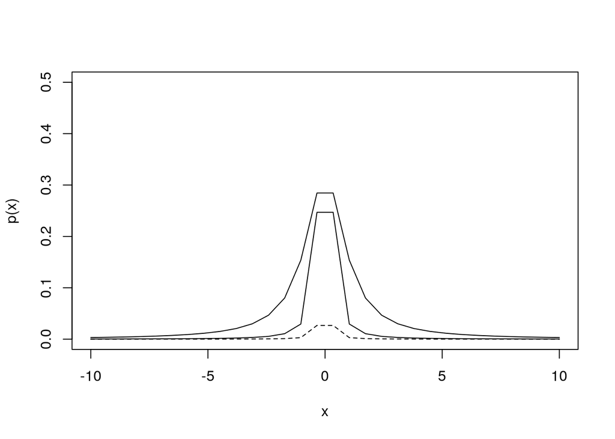

```r
x.seq <- seq( from=-10 , to=10 , length.out=30)
plot(x.seq,dcauchy(x.seq, 0,0.01),type="l", lty=2, ylim=c(0,0.5), xlab="x", ylab="p(x)")
lines(x.seq,dcauchy(x.seq, 0,0.1))
lines(x.seq,dcauchy(x.seq, 0,1))
```

```r
set.seed(1)
m9M2a <- ulam(
    alist(
        L ~ dnorm( mu , sigma ) ,
        mu <- a + b*R ,
        a ~ dcauchy( 0 , 1 ) ,
        b ~ dcauchy( 0 , 1 ) ,
        sigma ~ dexp( 1 )
    ) , data=d, chains=4 , cores=4)
```

```
## Trying to compile a simple C file
```

```r
m9M2b <- ulam(
    alist(
        L ~ dnorm( mu , sigma ) ,
        mu <- a + b*R ,
        a ~ dcauchy( 0 , 1 ) ,
        b ~ dcauchy( 0 , 0.1 ) ,
        sigma ~ dexp( 1 )
    ) , data=d, chains=4 , cores=4)
```

```
## Trying to compile a simple C file
```

```r
m9M2c <- ulam(
    alist(
        L ~ dnorm( mu , sigma ) ,
        mu <- a + b*R ,
        a ~ dcauchy( 0 , 1 ) ,
        b ~ dcauchy( 0 , 0.01 ) ,
        sigma ~ dexp( 1 )
    ) , data=d, chains=4 , cores=4 )
```

```
## Trying to compile a simple C file
```

```r
plot_rugged_prior <- function(model, d){
  prior <- extract.prior( model )

  plot( NULL , xlim=c(min(d$R),max(d$R)), ylim=c(min(d$L),max(d$L)) ,xlab="R",
        ylab="L" )
  abline( h=min(d$R) , lty=2 )
  abline( h=max(d$R) , lty=2 )

  R.seq <- seq( from=min(d$R) , to=max(d$R) , length.out=30 )
  mu <- link( model , post=prior , data=data.frame(R=R.seq) )
  for ( i in 1:50 ) lines( R.seq , mu[i,] , col=col.alpha("black",0.3) )
}
par(mfrow=c(1,3))
plot_rugged_prior(m9M2a, d)
```

```
## Trying to compile a simple C file
```

```r
plot_rugged_prior(m9M2b, d)
```

```
## Trying to compile a simple C file
```

```
## Trying to compile a simple C file
```

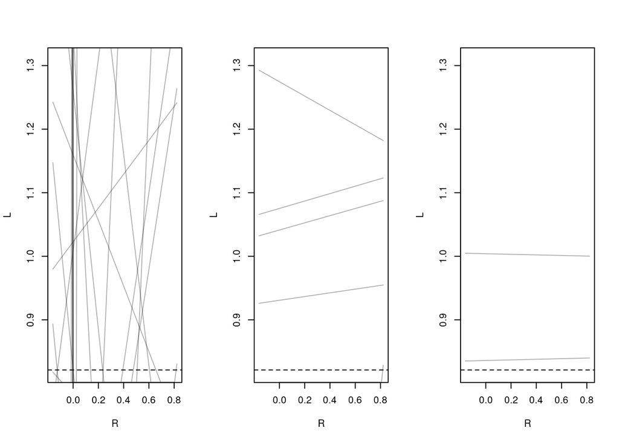

```r
plot_rugged_prior(m9M2c, d)
```

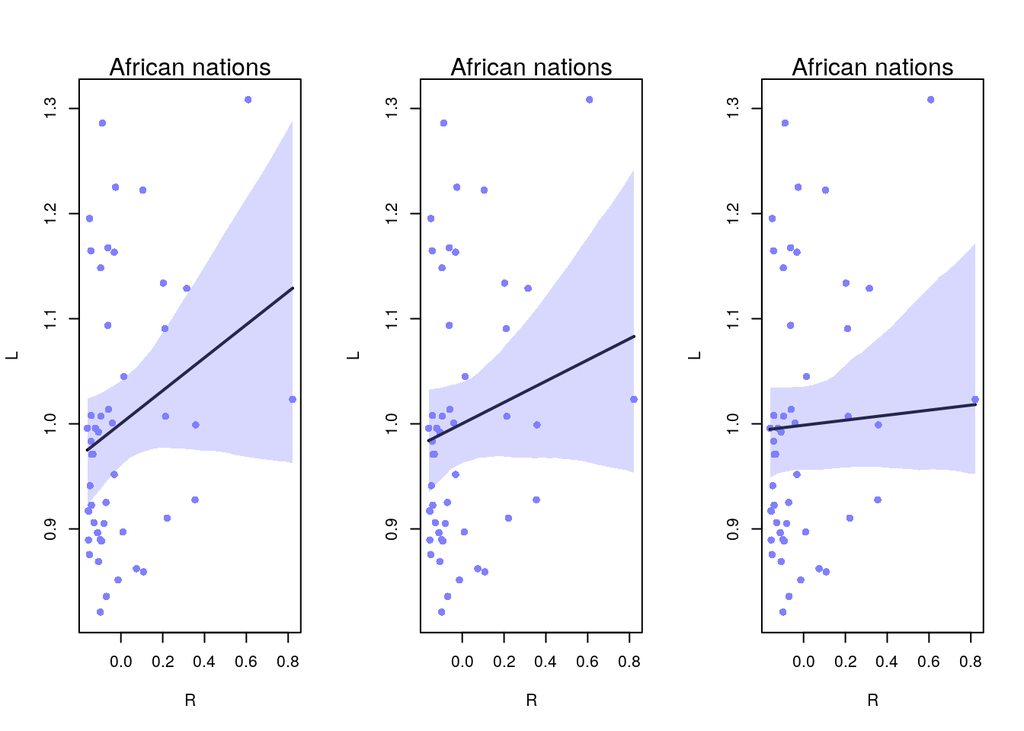

```r
par(mfrow=c(1,3))

plot_rugged_posterior(m9M2a,d)
plot_rugged_posterior(m9M2b,d)
plot_rugged_posterior(m9M2c,d)
```

```r
precis(m9M2a)
```

```
##            mean         sd       5.5%     94.5%    n_eff     Rhat4
## a     1.0002003 0.01817338 0.96985530 1.0294364 1890.873 1.0010896
## b     0.1568932 0.08845119 0.01362597 0.2934462 1754.780 0.9990148
## sigma 0.1245950 0.01307692 0.10592885 0.1469959 1534.742 1.0008631
```

```r
precis(m9M2b)
```

```
##            mean         sd        5.5%     94.5%    n_eff     Rhat4
## a     1.0001672 0.01777619  0.97184972 1.0288594 1469.681 1.0022870
## b     0.1009953 0.07763349 -0.01338449 0.2287120 1925.286 0.9997018
## sigma 0.1250945 0.01368489  0.10544705 0.1479809 1649.385 0.9990439
```

```r
precis(m9M2c)
```

```
##             mean         sd        5.5%     94.5%    n_eff    Rhat4
## a     0.99865998 0.01820530  0.96897633 1.0277596 730.4230 1.001466
## b     0.02390107 0.05008136 -0.01488758 0.1329432 195.2815 1.020115
## sigma 0.12790483 0.01339732  0.10793294 0.1511522 788.5741 1.000624
```

- The stronger the prior, the less slope as expected.

## 9M3.

Given: Rugged data.

Want: Compare the n_eff values. How much warmup is enough?

Sol.:

```r
l9M3 <- alist(
        L ~ dnorm( mu , sigma ) ,
        mu <- a + b*R ,
        a ~ dcauchy( 0 , 1 ) ,
        b ~ dcauchy( 0 , 1 ) ,
        sigma ~ dexp( 1 ))

m9M3a <- ulam(l9M3, data=d, chains=4 , cores=4, warmup=1)
```

```
## recompiling to avoid crashing R session
```

```
## Trying to compile a simple C file
```

```r
m9M3b <- ulam(l9M3, data=d, chains=4 , cores=4, warmup=10)
```

```
## recompiling to avoid crashing R session
## Trying to compile a simple C file
```

```r
m9M3c <- ulam(l9M3, data=d, chains=4 , cores=4, warmup=100)
```

```
## recompiling to avoid crashing R session
## Trying to compile a simple C file
```

```r
precis(m9M3a)
```

```
##             mean        sd       5.5%    94.5%    n_eff        Rhat4
## a      1.0001243 0.1819715  0.7115265 1.207855 2.003008 8.560736e+13
## b     -0.1754190 1.2774326 -2.1588806 1.404663 2.003008 9.705256e+14
## sigma  0.9991781 0.4278854  0.5243132 1.675602 2.003008 2.104988e+14
```

```r
precis(m9M3b)
```

```
##            mean         sd         5.5%     94.5%    n_eff    Rhat4
## a     0.9848218 0.17828939  0.967798305 1.0271500 103.5327 1.025491
## b     0.1653693 0.18172102 -0.006069432 0.3121423 104.7652 1.033857
## sigma 0.1304047 0.06744751  0.104413380 0.1504556 118.0440 1.024005
```

```r
precis(m9M3c)
```

```
##            mean         sd       5.5%     94.5%    n_eff    Rhat4
## a     0.9996564 0.01836995 0.97072531 1.0296343 3608.571 1.001034
## b     0.1555173 0.08305005 0.02261899 0.2857044 1569.607 1.000962
## sigma 0.1243370 0.01286784 0.10513728 0.1464315 1235.727 1.002973
```

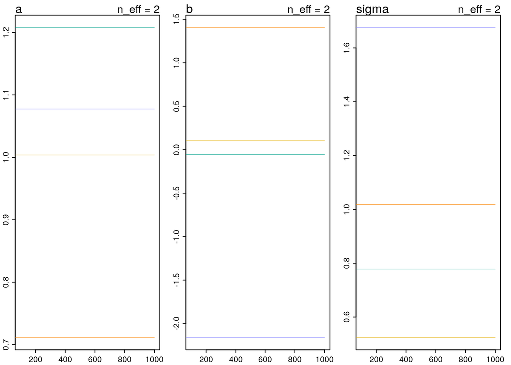

```r
traceplot(m9M3a)
```

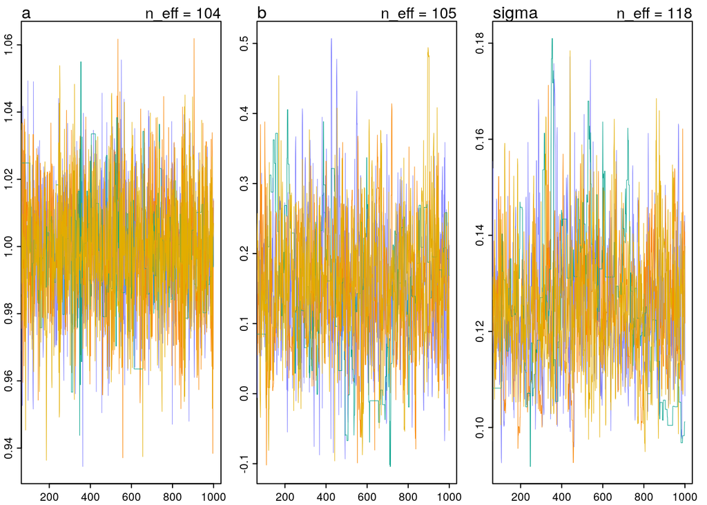

```r
traceplot(m9M3b)
```

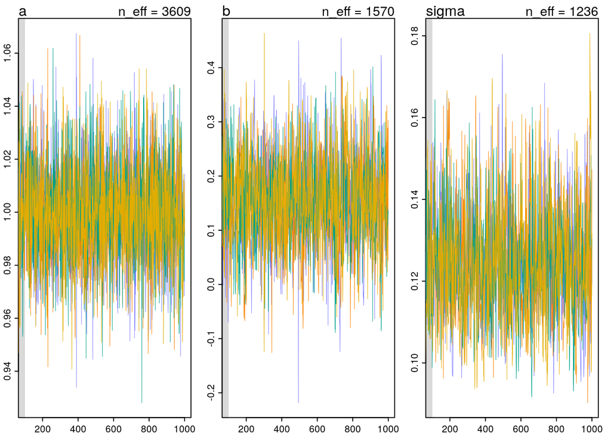

```r
traceplot(m9M3c)
```

- According to the traceplots, and the R-hat values, 100 warmup iterations are enough.

## 9H1.

Given:

```r
mp <- ulam(
  alist(
    a ~ dnorm(0,1),
    b ~ cauchy(0,1)
  ),
  data=list(y=1),
  start=list(a=0,b=0),
  iter=1e4, warmup=100)
```

```
## Trying to compile a simple C file
```

Want: Run the model below and then inspect the posterior distribution and explain what it is accomplishing. Compare the samples for the parameters a and b . Can you explain the different trace plots, using what you know about the Cauchy distribution?

Sol.:

- It samples 10000 values from a standard normal distribution and 10000 values from a Cauchy distribution with location 0 and scale 1.

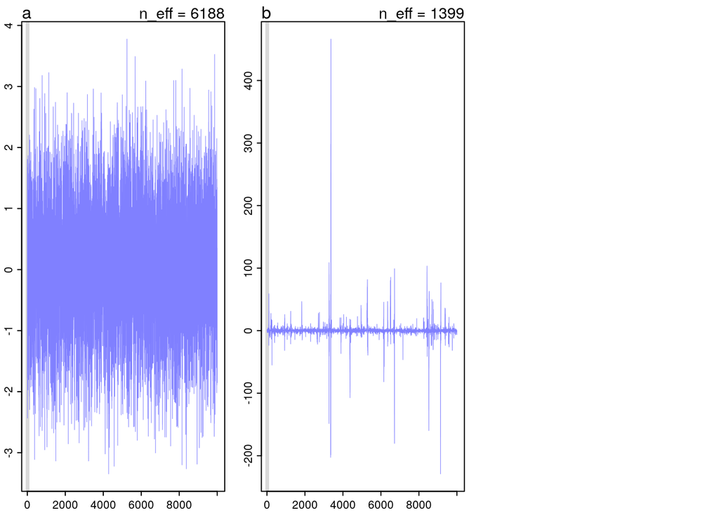

```r
traceplot(mp)
```

```r
precis(mp)
```

```
##          mean        sd      5.5%    94.5%    n_eff     Rhat4
## a 0.008614205  1.013844 -1.643552 1.618222 6187.933 0.9998994
## b 0.357307039 15.981390 -5.020480 6.481086 1399.363 1.0002877
```

## 9H2.

Given: Divorce rates.

Want: Compare models m5.1, m5.2, m5.3 with ´ulam´.

Sol.:

```r
library(rethinking)
data(WaffleDivorce)
d <- WaffleDivorce

# standardize variables
d$D <- standardize( d$Divorce )
d$M <- standardize( d$Marriage )
d$A <- standardize( d$MedianAgeMarriage )
d <- d[, c("D","A","M")]
```

```r
l5.1 <- alist(
        D ~ dnorm( mu , sigma ) ,
        mu <- a + bA * A ,
        a ~ dnorm( 0 , 0.2 ) ,
        bA ~ dnorm( 0 , 0.5 ) ,
        sigma ~ dexp( 1 )
    )

l5.2 <- alist(
        D ~ dnorm( mu , sigma ) ,
        mu <- a + bM * M ,
        a ~ dnorm( 0 , 0.2 ) ,
        bM ~ dnorm( 0 , 0.5 ) ,
        sigma ~ dexp( 1 )
    )

l5.3 <- alist(
        D ~ dnorm( mu , sigma ) ,
        mu <- a + bM*M + bA*A ,
        a ~ dnorm( 0 , 0.2 ) ,
        bM ~ dnorm( 0 , 0.5 ) ,
        bA ~ dnorm( 0 , 0.5 ) ,
        sigma ~ dexp( 1 )
    )
```

```r
m5.1q <- quap(l5.1, data=d)
m5.2q <- quap(l5.2, data=d)
m5.3q <- quap(l5.3, data=d)
```

```r
m5.1u <- ulam(l5.1, data=d, chains=4 , cores=4, log_lik = TRUE)
```

```
## Trying to compile a simple C file
```

```r
m5.2u <- ulam(l5.2, data=d, chains=4 , cores=4, log_lik = TRUE)
```

```
## Trying to compile a simple C file
```

```r
m5.3u <- ulam(l5.3, data=d, chains=4 , cores=4, log_lik = TRUE)
```

```
## Trying to compile a simple C file
```

```r
compare(m5.1q, m5.1u)
```

```
##           WAIC       SE     dWAIC      dSE    pWAIC    weight
## m5.1u 125.9865 12.67862 0.0000000       NA 3.733679 0.5997434
## m5.1q 126.7953 14.06267 0.8087921 1.402732 4.347639 0.4002566
```

```r
compare(m5.2q, m5.2u)
```

```
##           WAIC        SE     dWAIC      dSE    pWAIC    weight
## m5.2u 139.2911  9.823997 0.0000000       NA 2.962639 0.5710928
## m5.2q 139.8637 10.869234 0.5726223 1.065238 3.374374 0.4289072
```

```r
compare(m5.3q, m5.3u)
```

```
##           WAIC       SE    dWAIC     dSE    pWAIC    weight
## m5.3u 127.5324 12.67419 0.000000      NA 4.717321 0.6685326
## m5.3q 128.9356 14.61559 1.403111 1.98821 5.665663 0.3314674
```

- In terms of WAIC values the MCMC models perform better than their quadratic approximation counterparts.
- In each case the difference is not reliable because dSE > dWAIC.

## 9H3.

Given: Leg length example in Chapter 5.

Want: Fit with MCMC with `constraints=list(br="lower=0")` and without. Compare beta parameters.

Sol.:

```r
N <- 100
height <- rnorm(N, 10, 2)
leg_prop <- runif(N, 0.4, 0.5)
leg_left <- leg_prop * height + rnorm( N, 0 , 0.02)
leg_right <- leg_prop * height * rnorm(N, 0, 0.02)

d <- data.frame( height, leg_left, leg_right)
```

```r
l5.8 <- alist(
  height ~ dnorm(mu, sigma),
  mu <- a + bl*leg_left + br*leg_right,
  a ~ dnorm( 10, 100),
  bl ~ dnorm( 2, 10),
  br ~ dnorm( 2, 10),
  sigma ~ dexp(1)
)
start_values <- list(a=10, bl=0, br=0.1, sigma=1)
```

```r
set.seed(1)
m5.8s <- ulam(l5.8, data=d, chains = 4, cores = 4,
              start=start_values,
              log_lik = TRUE)
```

```
## Trying to compile a simple C file
```

```r
m5.8s2 <- ulam(l5.8, data=d, chains = 4, cores = 4,
              constraints = list(br="lower=0"),
              start=start_values,
              log_lik = TRUE)
```

```
## Trying to compile a simple C file
```

```r
precis(m5.8s)
```

```
##            mean         sd       5.5%    94.5%     n_eff    Rhat4
## a     0.8187686 0.30446743  0.3179348 1.285774  882.5360 1.006077
## bl    2.0377629 0.06680227  1.9341957 2.147341  886.6704 1.005382
## br    0.9338136 0.66042471 -0.1255745 1.999440 1060.0782 1.000320
## sigma 0.5918130 0.04300169  0.5273531 0.663537 1141.1627 1.000569
```

```r
precis(m5.8s2)
```

```
##            mean         sd      5.5%     94.5%     n_eff    Rhat4
## a     0.8167673 0.29942479 0.3571010 1.3030093  604.0269 1.005221
## bl    2.0377930 0.06650138 1.9280942 2.1416009  614.1177 1.005428
## br    1.0787848 0.55304115 0.2456572 2.0378049  745.7789 1.001800
## sigma 0.5897981 0.04276513 0.5279925 0.6620547 1100.1116 1.000756
```

## 9H4.

Given: 9H3.

Want: Use WAIC or PSIS to compare effective number of parameters.

Sol.:

```r
compare(m5.8s, m5.8s2)
```

```
##            WAIC       SE     dWAIC       dSE    pWAIC    weight
## m5.8s2 181.2442 10.58595 0.0000000        NA 3.229536 0.5387782
## m5.8s  181.5550 10.49141 0.3108499 0.4585377 3.365475 0.4612218
```

## 9H5.

Given: Metropolis algorithm.

Want: Modify such that the island populations have a different distribution than the island labels.

Sol.:

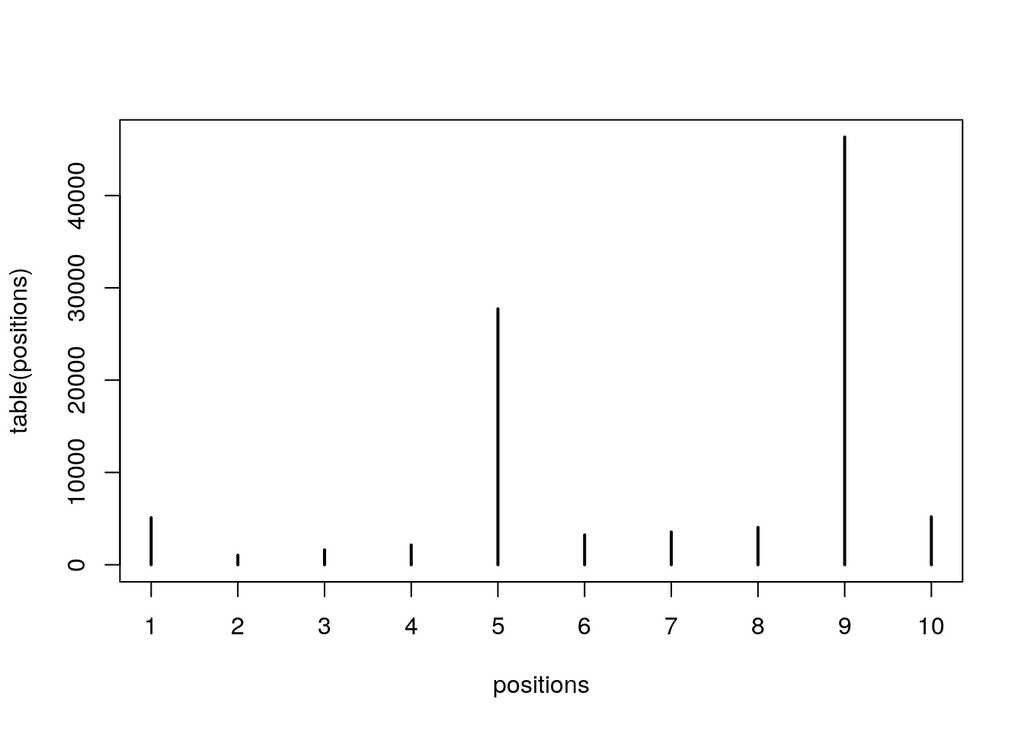

```r
populations <- c(10,2,3,4,50,6,7,8,90,10)
num_weeks <- 1e5
positions <- rep(0,num_weeks)
current <- 10
for ( i in 1:num_weeks ) {
  ## record current position
    positions[i] <- current
  ## flip coin to generate proposal
    proposal <- current + sample( c(-1,1) , size=1 )
  ## now make sure he loops around the archipelago
    if ( proposal < 1 ) proposal <- 10
    if ( proposal > 10 ) proposal <- 1
  ## move?
    prob_move <- populations[proposal]/populations[current]
    current <- ifelse( runif(1) < prob_move , proposal , current )
}

#par(mfrow=c(1,2))
#plot( 1:100 , positions[1:100] )

plot( table( positions ) )
```

```r
#dens(positions)
```

## 9H6.

Given: Globe example: $k=8$, $n=15$.

Want: $P(p\mid k,n)$ with Metropolis algorithm.

Sol.:

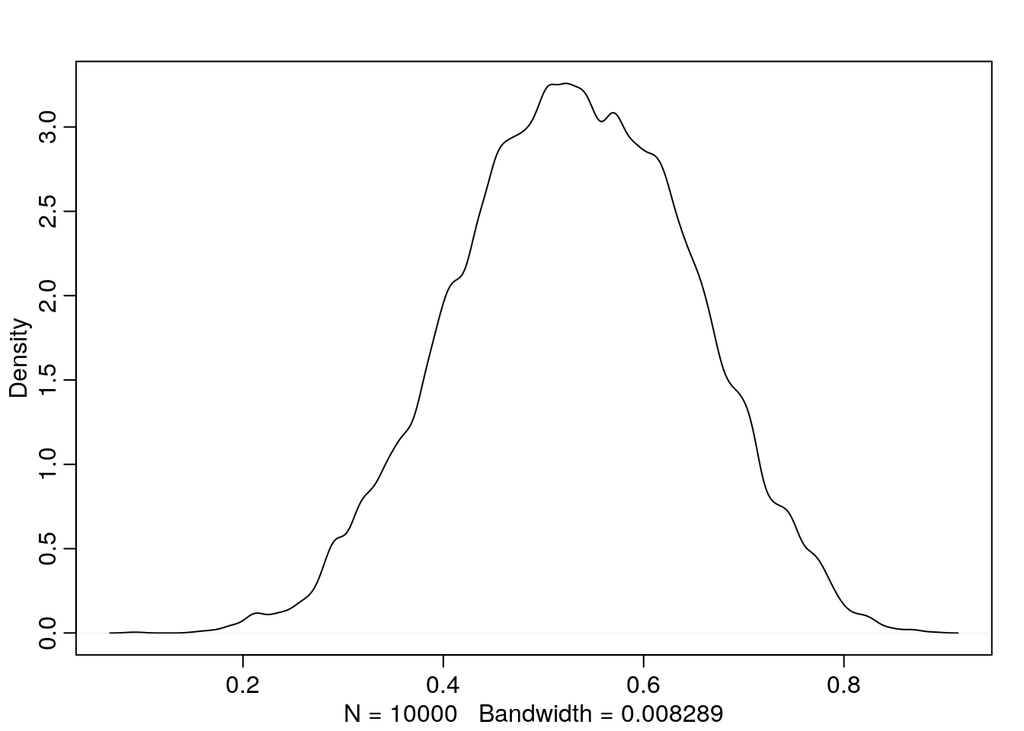

```r
# Original grid solution from chapter 3 for comparison.
get_grid_samples <- function(k,n){
  num_grid_points <- 1000
  p_grid <- seq( from=0 , to=1 , length.out=num_grid_points)
  prior <- rep(1,num_grid_points)
  likelihood <- dbinom( k , size=n , prob=p_grid )
  posterior <- likelihood * prior
  posterior <- posterior / sum(posterior)
  samples <- sample( p_grid , size=1e4 , replace=TRUE , prob=posterior )
  return(samples)
}
set.seed(3)
samples <- get_grid_samples(8, 15)

dens( samples )
```

```r
HPDI( samples , prob=0.90 )
```

```
##      |0.9      0.9|
## 0.3353353 0.7167167
```

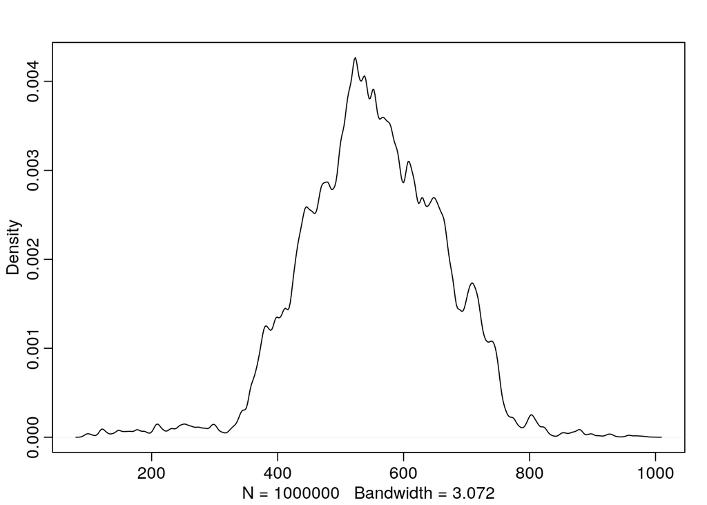

```r
set.seed(3)

n <- 15
k <- 8
num_grid_points <- 1000

p_grid <- seq( from=0 , to=1 , length.out=num_grid_points)
likelihood <- dbinom( k , size=n , prob=p_grid )

num_samples <- 1e6
samples <- rep(0,num_samples)
current <- num_grid_points
for ( i in 1:num_samples ) {
    samples[i] <- current
    proposal <- current + sample( c(-1,1) , size=1 )
    if ( proposal < 1 ) proposal <- num_grid_points
    if ( proposal > num_grid_points ) proposal <- 1
    prob_move <- likelihood[proposal]/likelihood[current]
    current <- ifelse( runif(1) < prob_move , proposal , current )
}

dens( samples )
```

```r
HPDI( samples/num_grid_points , prob=0.90 )
```

```
##  |0.9  0.9|
## 0.376 0.718
```